# R-functionality

Statistical Programming with R

## This lecture:

- `R` functionality
  - The blueprint of `R`
  - Workspaces and projects
  - Classes
- Reading in and exporting data

## The blueprint of `R`

## Layers in `R`

There are several ‘layers’ in `R`. Some layers you are allowed to fiddle around in, some are forbidden. In general there is the following distinction:

- The global environment.
- User environments
- Functions
- Packages
- Namespaces

## Environments

The global environment can be seen as a olympic-size swimming pool. Everything you do has its place there.

If you’d like, you may create another, separate environment to work in.

- A user environment would by default not have access to other environments

## Functions

- If you create a function, it is positioned in the global environment.
- Everything that happens in a function, stays in a function. Unless you specifically tell the function to share the information with the global environment.
- See functions as a shampoo bottle in a swimming pool to which you add some water. If you’d like to see the color of the mixture, you’d have to squeeze the bottle for it to come out.

## Packages

- Packages have their own space.
  - Everything needed to run the functions in a package is needly contained within its own space
  - See packages as separate (mini) pools that are connected to the main pool (the global environment)

## Loading packages

There are two ways to load a package in `R`

```r
library(stats)
```

and

```r
require(stats)
```

`require()` will produce a warning when a package is not found. In other words, it will not stop as function `library()` does.

## Installing packages

The easiest way to install e.g. package `mice` is to use

```r
install.packages("mice")
```

Alternatively, you can also do it in `RStudio` through

`Tools --> Install Packages`

## Namespaces

- Namespaces. These are the deeper layers that feed new water to the surface of the mini pools.
  - Packages can have namespaces.
  - Functions within packages are executed within the package or namespace and have access to the global environment.
  - Objects in the global environment that match objects in the function’s namespace are ignored when running functions from packages!

## `R` in depth

## Workspaces and why you should (generally) *not* save them

A workspace contains all changes you made to environments, functions and namespaces.

A saved workspace contains everything at the time of the state wherein it was saved.

You can reload a saved workspace and continue working at a later point

When you exit an R session, you’re faced with the question of whether or not to save your workspace. *You should almost never answer yes*.

### Why not to save?

- *Code* is reproducible and logical
- A *saved workspace* is whatever you did earlier and then forgot about

## Workspaces and how not to save them


## History

`R` by default saves (part of) the code history and `RStudio` expands this functionality greatly.

Most often it may be useful to look back at the code history for various reasons.

- There are multiple ways to access the code history.
  1. Use arrow up in the console. This allows you to go back in time, one codeline by one. Extremely useful to go back to previous lines for minor alterations to the code.
  2. Use the history tab in the environment pane. The complete project history can be found here and the history can be searched. This is particularly convenient when you know what code you are looking for.

## Working in projects in `RStudio`

`R` has a notion of the **working directory**. This is where `R` will look for, and save, files unless directed elsewhere

You can set your working directory manually with `setwd()`. But for a better, more stable and reproducible workflow, use **projects**:

[figure not shown]

## Working in projects in `RStudio`

- Every project has its own history
- Every project can have its own version control system
- When opening a project, this sets the working directory in the same folder
- When working in a project, files belonging to the same project are stored together

## Classes

## Classes in R

Remember the `boys` data from package `mice`:

```r
library(mice)
class(boys)
```

```
## [1] "data.frame"
```

```r
model <- lm(bmi ~ I(wgt / (hgt / 100)^2), data = boys)
class(model)
```

```
## [1] "lm"
```

## Classes in R

Classes are used for an object-oriented style of programming. This means that you can write a specific function that - has fixed requirements with respect to the input. - presents output or graphs in a predefined manner.

When a generic function fun is applied to an object with class attribute `c("first", "second")`, the system searches for a function called `fun.first` and, if it finds it, applies it to the object.

If no such function is found, a function called `fun.second` is tried. If no class name produces a suitable function, the function fun.default is used (if it exists). If there is no class attribute, the implicit class is tried, then the default method.

## Classes example: plotting without class

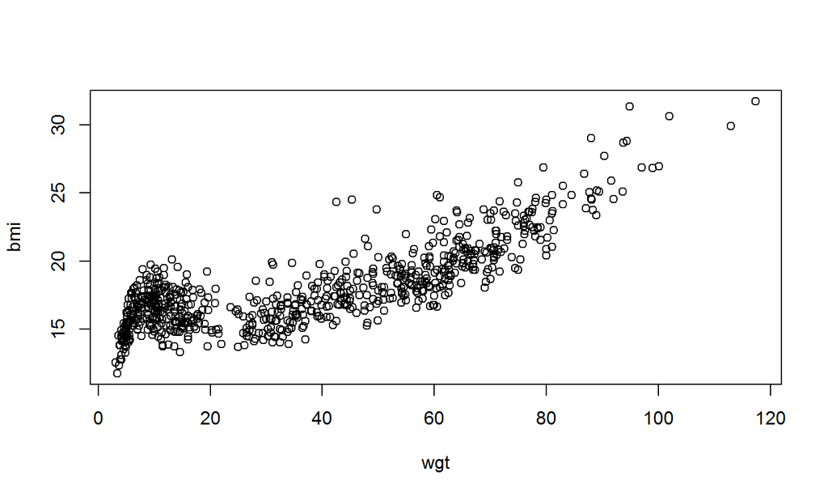

```r
plot(bmi ~ wgt, data = boys)
```

## Classes example: plotting with class

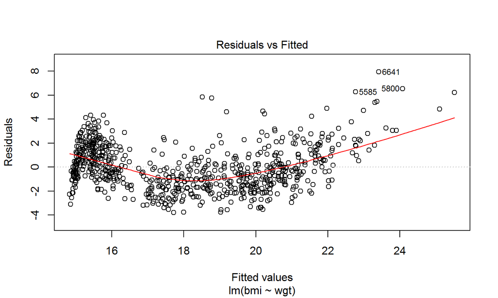

```r
plot(lm(bmi ~ wgt, data = boys), which = 1)
```

## Classes example: plotting with class

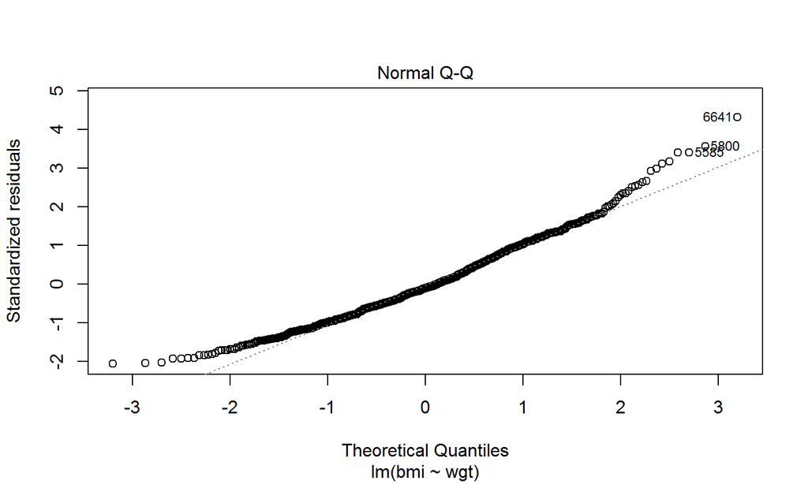

```r
plot(lm(bmi ~ wgt, data = boys), which = 2)
```

## Classes example: plotting with class

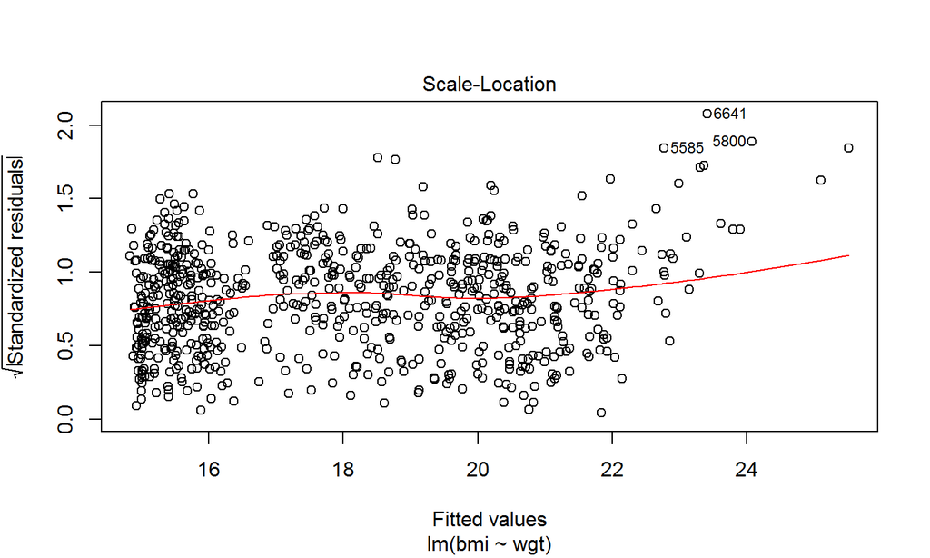

```r
plot(lm(bmi ~ wgt, data = boys), which = 3)
```

## Classes example: plotting with class

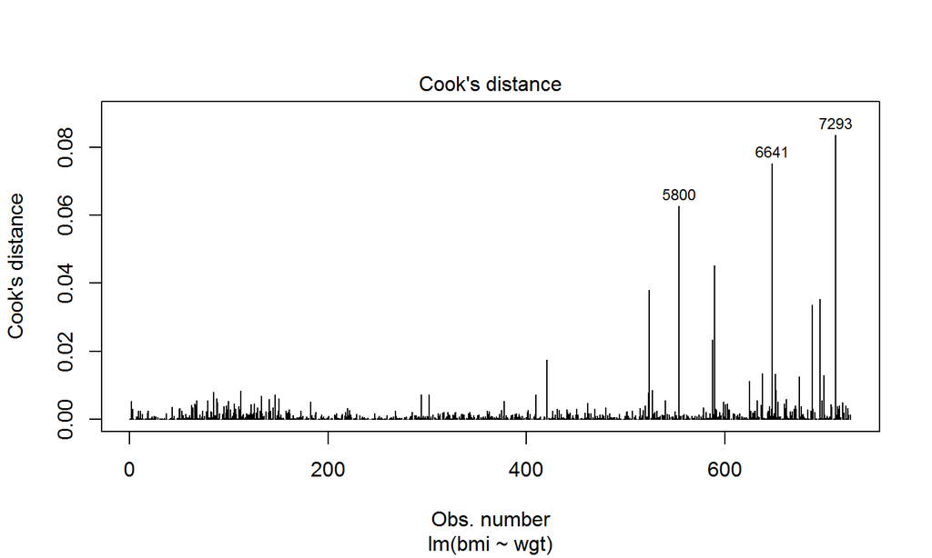

```r
plot(lm(bmi ~ wgt, data = boys), which = 4)
```

## Classes example: plotting with class

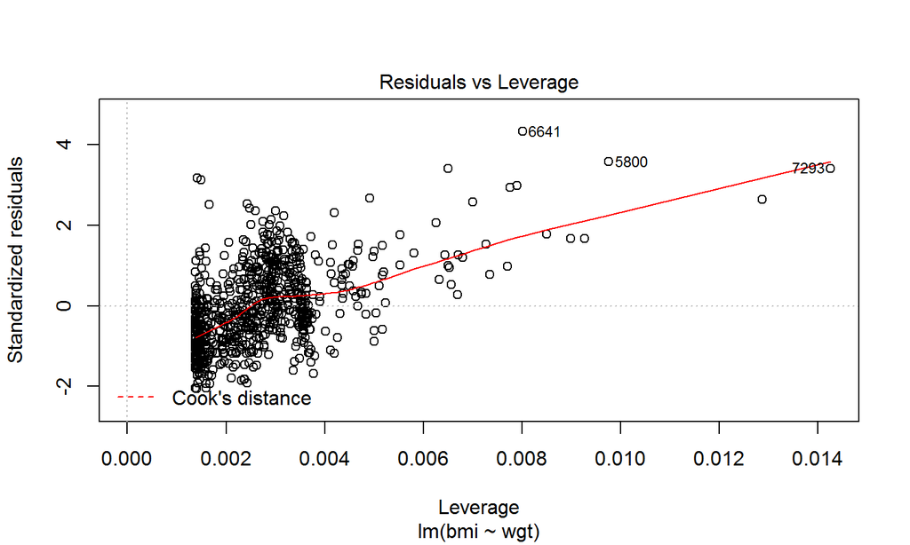

```r
plot(lm(bmi ~ wgt, data = boys), which = 5)
```